# Estadística Descriptiva: Estadísticos

Edimer David Jaramillo

13 de febrero de 2018

# Medidas de resumen para una variable

Las medidas de resumen permiten caracterizar la información que aportan los $n$ datos de la muestra considerada.

## Medidas de tendencia central

Las medidas de centralización son las más importantes, aunque no basta con ellas para resumir la información. Los **estadísticos** o **valores típicos** pretenden caracterizar o describir la muestra, indicando el valor de la variable hacia el cual tienden a agruparse los datos.

- **Media aritmética ($\bar{x}$):** el promedio es la suma de los valores $x_{i}$ de las observaciones dividido por el tamaño $n$ de la muestra.
  $$\begin{equation*}
  \bar{x}=\frac{\sum\nolimits_{i=1}^nxi}{n}=\frac{x_{1}+x_{2}+...+x_{n}}{n}
  \end{equation*}$$
  - La media es susceptible a valores extremos.
  - Cuando se tienen variables discretas, es posible que el resultado de $\bar{x}$ no pertenezca al conjunto de valores posibles (*ej.* el número de hermanos).
- **Mediana ($Me$):** la mediana es el valor central en el sentido del orden. La mediana deja por encima y por debajo de ella, el 50% de los datos.
  - No se afecta por valores extremos.
  - En distribuciones simétricas, la media es aproximadamente igual a la mediana.
  - En distribuciones con sesgo a la derecha (sesgo positivo), la media tiende a ser mayor que la mediana.
  - En distribuciones con sesgo a la izquierda (sesgo negativo) la media tiede a ser menor que la mediana.
- **Moda ($Mo$):** la moda es el valor que ocurre con mayor frecuencia, es decir, el dato que más se repite.
  - Unimodal: una sola moda
  - Bimodal: dos modas
  - Multimodal: más de dos modas
- **Media ponderada ($Mp$):** es una medida donde todas las observaciones no poseen el mismo grado de importancia.

## Medidas de dispersión

Estas medidas expresan el grado de homogeneidad o heterogeneidad de los datos en torno a un valor central.

- **Rango:** es la diferencia entre el valor máximo y el mínimo
- **Varianza($S^2$):** proporciona una medida de dispersión relativa al tamaño muestral de las distintas observaciones respecto a la media aritmética $\bar{x}$. Se define como la suma de los cuadrados de las diferencias entre cada valor de la muestra y su media.
  - Para la población:
    $$\begin{equation*}
    \sigma^2=\frac{\sum\nolimits_{i=1}^n(x_{i}-\bar{x})}{N}^2
    \end{equation*}$$
  - Para la muestra:
    $$\begin{equation*}
    S^2=\frac{\sum\nolimits_{i=1}^n(x_{i}-\bar{x})}{n-1}^2
    \end{equation*}$$
- **Desviación estándar($S$):** se define como la raíz cuadrada de la varianza.
  - Para la población:
    $$\sigma=\sqrt{\sigma^2}$$
  - Para la muestra:
    $$S=\sqrt{S^2}$$
- **Coeficiente de variación($CV$):** se define como el cociente entre la desviación típica y la media aritmética, expresado en porcentaje.
  $$CV=(S/\bar{x})*100$$

## Ejemplos

- **Ejemplo 1.1 [G4]:** Los métodos de extracción de fósforo (P) del suelo, difieren en su capacidad o poder de extracción según la naturaleza de los suelos. En la siguiente tabla se presentan los datos de diferentes regiones de Colombia para los cuales se efectuó la extracción de fósforo (en tipos de suelo diferentes) mediante tres métodos de extracción (Método A, B y C). Los resultados están dados en partes por millón (ppm).

| Región | Suelo | Método A | Método B | Método C |
| --- | --- | --- | --- | --- |
| Sabana de Bogotá | Inceptisol | 13.2 | 32.8 | 16.0 |
| Sabana de Bogotá | Andisol | 1.1 | 1.3 | 1.0 |
| Llanos Orientales | Oxisol | 3.7 | 3.9 | 4.0 |
| Oriente Antioqueño | Andisol | 1.5 | 2.3 | 2.5 |
| Zona cafetera | Andisol | 4.1 | 8.1 | 4.5 |
| Popayán | Andisol | 2.0 | 3.0 | 2.5 |
| Antioquia | Ultisol | 1.6 | 1.5 | 2.5 |

Calcular:

- La media y la mediana del contenido de fósforo para cada método de extracción.
- ¿Cuál de los tipos de suelo presenta el valor mínimo y máximo de extracción?
- El rango de contenido de fósforo para cada método de extracción.
- La varianza para cada método de extracción.
- La desviación estándar para cada método de extracción.
- ¿Cuál de los tres métodos de extracción presenta mayor dispersión?
- En promedio, ¿cuál de las regiones presenta mayor ppm de fósforo extraido?
- ¿Cuál de los tipos de suelo presenta mayor media para los niveles de fósforo extraido?
- **Ejemplo 1.2 [G5]:** Usted ha sido encargado por el dueño de dos sistemas de producción avícola, ubicados en dos zonas diferentes del país, donde se pretende caracterizar cada sistema productivo con base en los registros obtenidos para la ganancia diaria de peso (en gramos) por ave entre las semanas 0 a 20, sometidos a dos dietas diferentes. Los datos se presentan en la siguiente tabla:

| Zona | Sexo | Dieta | GDP |
| --- | --- | --- | --- |
| 1 | Hembra | A | 29.2 |
| 1 | Hembra | A | 27.3 |
| 1 | Hembra | A | 31.5 |
| 1 | Hembra | B | 28.9 |
| 1 | Hembra | B | 26.1 |
| 1 | Hembra | B | 27.8 |
| 1 | Macho | A | 31.7 |
| 1 | Macho | A | 29.9 |
| 1 | Macho | A | 33.4 |
| 1 | Macho | B | 29.3 |
| 1 | Macho | B | 32.5 |
| 1 | Macho | B | 28.7 |
| 2 | Hembra | A | 26.3 |
| 2 | Hembra | A | 27.9 |
| 2 | Hembra | A | 27.8 |
| 2 | Hembra | B | 26.9 |
| 2 | Hembra | B | 27.1 |
| 2 | Hembra | B | 29.3 |
| 2 | Macho | A | 31.2 |
| 2 | Macho | A | 33.1 |
| 2 | Macho | A | 32.1 |
| 2 | Macho | B | 27.8 |
| 2 | Macho | B | 29.5 |
| 2 | Macho | B | 30.6 |

Se pide responder a las siguientes preguntas:

1. En promedio, ¿cuál de las dos zonas presenta mayor GDP?
2. En promedio, ¿cuál de los sexos presenta mayor GDP?
3. En promedio, ¿cuál de las dos dietas presenta mayor GDP?
4. Para cada zona, ¿el comportamiendo de la GDP promedio es igual entre hembras y machos?
5. Para cada zona, ¿el comportamiento de la GDP promedio es igual entre ambas dietas?
6. ¿Cuál es la mediana y la moda de cada zona?
7. ¿Cuál es la varianza de cada zona, dieta y sexo?
8. ¿Cuál es la desviación estándar de cada zona, dieta y sexo?
9. ¿Cuál es el rango de la GDP?
10. En términos porcentuales, ¿cuál es la dispersión de cada zona, dieta y sexo?

## Medidas de posición

Los cuantiles indican la posición relativa de un dato con respecto al resto de la muestra.

- **Percentiles:** dividen la muestra en 100 partes iguales. Son los valores que dejan determinado porcentaje de observaciones por debajo de ellos. Por ejemplo, el percentil 10, es el valor superior al 10% de los datos, pero inferior al 90% restante.

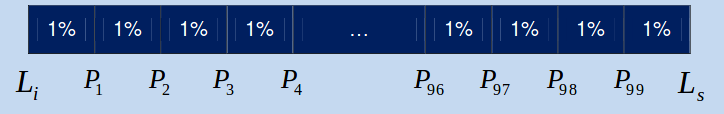

Ubicación del percentil $k$:
$$P_{k}=\frac{k(n+1)}{100}$$

- **Cuartiles:** dividen la muestra en cuatro partes iguales.
  - Cuartil 1: 25% de las observaciones
  - Cuartil 2: 50% de las observaciones
  - Cuartil 3: 75% de las observaciones

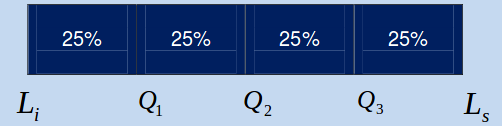

Ubicación del cuartil $k$:
$$Q_{k}=\frac{k(n+1)}{4}$$

- **Deciles:** dividen la muestra en 10 partes iguales.

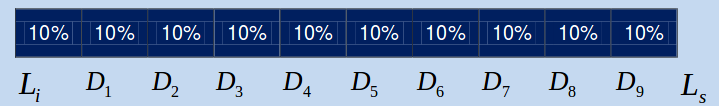

Ubicación del decil $k$:
$$D_{k}=\frac{k(n+1)}{10}$$

- **Rango intercuartil:** el rango intercuartílico (RIQ) se obtiene como la diferencia entre los cuartiles 3 (Q3) y 1 (Q1). La mitad de las observaciones se clasifican dentro de este rango.

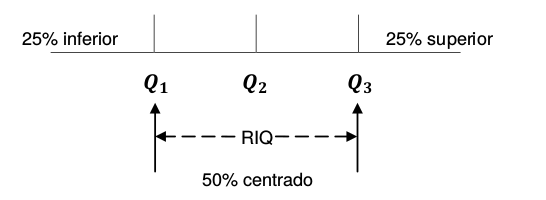

$$RIQ\ =\ Q3-Q1$$

### Ejemplos

- **Ejemplo 1.3 [G4]:** se desea caracterizar mediante percentiles, deciles y cuartiles los siguientes registros de peso al nacimiento (en kilogramos) para 30 bovinos del trópico bajo colombiano.

| Peso | Peso | Peso | Peso | Peso | Peso |
| --- | --- | --- | --- | --- | --- |
| 27 | 37 | 38 | 42 | 35 | 25 |
| 24 | 29 | 31 | 29 | 39 | 42 |
| 46 | 47 | 39 | 44 | 41 | 42 |
| 38 | 36 | 46 | 45 | 44 | 43 |
| 51 | 38 | 42 | 43 | 47 | 53 |

Se debe responder a las siguientes preguntas:

1. ¿Qué peso al nacimiento corresponde con el $Q2$, $D5$ y $P50$?
2. ¿Cuál es la mediana?
3. ¿El 70% de los datos está por encima de qué peso al nacimiento?
4. ¿El 30% de los datos está por encima de qué peso al nacimiento?
5. ¿el 10% de los registros para peso al nacimiento está por encima de qué valor?
6. ¿Cuál es el rango intercuartilico?
- **Ejemplo 1.4 [G5]:** Con la siguiente serie de datos correspondiente a pesajes de leche (en kilogramos), calcular:
1. El valor correspondiente al $Q2$, $D5$ y $P50$.
2. El valor del percentil 85.
3. El valor del cuartil 3 y 1.
4. El rango intercuartílico.

| Leche | Leche |
| --- | --- |
| 12 | 14 |
| 15 | 17 |
| 16 | 15 |
| 18 | 13 |
| 21 | 14 |
| 22 | 18 |
| 16 | 21 |
| 17 | 23 |
| 18 | 24 |

## Medidas de distribución o forma

- **Coeficiente de asimetría ($g_{1}$):** indica el grado de simetría de la distribución de datos. Puede ser:
  - Distribución simétrica $si\ g_{1} = 0$
  - Distribución asimétrica negativa $si\ g_{1} < 0$
  - Distribución asimétrica positiva $si\ g_{1} > 0$

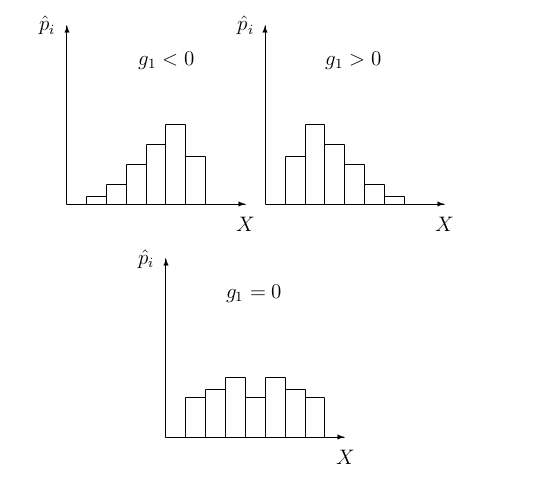

La fórmula de cálculo del coeficiente de asimetría es la siguiente:

$$\begin{equation*}
g_{1}=\left[\frac{{n}}{(n-1)(n-2)}\right]\left[\frac{\sum\nolimits_{i=1}^n(x_{i}-\bar{x})^3}{S^3}\right]
\end{equation*}$$

- **Coeficiente de curtosis ($g_{2}$):** evalua el grado de concentración de los datos alrededor de la media y de los extremos (o colas). Puede ser:
  - Distribución mesocúrtica $si\ g_{2}=0$
  - Distribución leptocúrtica $si\ g_{2}>0$
  - Distribución platicúrtica $si\ g_{2}<0$

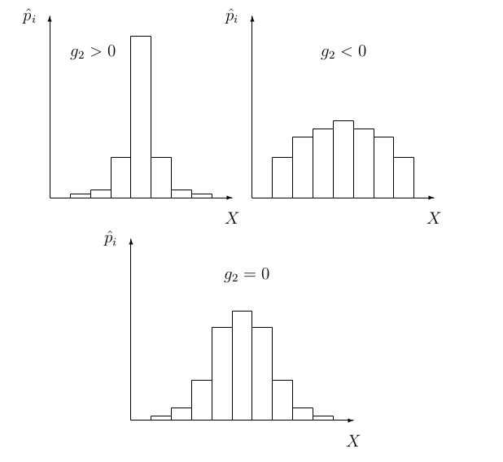

La fórmula de cálculo del coeficiente de curtosis es la siguiente:

$$\begin{equation*}
g_{2}=\left[\frac{{n(n+1)}}{(n-1)(n-2)(n-3)}\right]\left[\frac{\sum\nolimits_{i=1}^n(x_{i}-\bar{x})^4}{S^4}\right]-\left[\frac{{3(n-1)^2}}{(n-2)(n-3)}\right]
\end{equation*}$$

### Ejemplos

- **Ejemplo 1.5 [G4]:** se tiene interés sobre la distribución de la siguiente serie de datos correspondientes al peso del huevo (en gramos) de dos avícolas diferentes.

| Avícola A | Avícola B |
| --- | --- |
| 55 | 42 |
| 48 | 38 |
| 52 | 56 |
| 62 | 45 |
| 71 | 31 |
| 68 | 38 |
| 52 | 39 |
| 44 | 41 |
| 45 | 51 |
| 57 | 56 |
| 56 | 62 |
| 51 | 44 |
| 54 | 48 |
| 59 | 59 |
| 42 | 50 |

Calcular:

1. El coeficiente asimetría para ambas avícolas
2. El coeficiente de curtosis para ambas avícolas
3. ¿Son simétricas las distribuciones de los pesos del huevo en ambas avícolas?
- **Ejemplo 1.6 [G5]:** se tiene interés sobre la distribución de la siguiente serie de datos correspondientes al tamaño de camada en porcinos.

| Tamaño de camada |
| --- |
| 5 |
| 8 |
| 12 |
| 11 |
| 10 |
| 9 |
| 8 |
| 7 |
| 13 |
| 12 |
| 9 |
| 11 |

Calcular:

1. El coeficiente asimetría.
2. El coeficiente de curtosis.
3. ¿Qué tipo de distribución se evidencia en los datos?

## Relación de media, mediana y moda

- **Distribuciones simétricas:**
  $$\bar{x}=Me=Mo$$
- **Distribuciones asimétricas negativas:**
  $$Mo>Me>\bar{x}$$
- **Distribuciones asimétricas positivas:**
  $$Mo<Me<\bar{x}$$